# R with R studio: An introduction

R with R studio: An introduction Jason Tsai and Steve Doyle 23rd May 2023

## Overview and aims

The goal for this module is to help you to learn the basics of using R so you can go away and start to tackle your own data. R is a programming language that was first launched back in 2000. There are many reasons to use R:

- it is easy to use and has excellent graphic capabilities
- it has lots of new statistical methods to be used in a straightforward manner
- it’s **open source** and **free**.
- because of ⬆️, it is supported by a large user network.
- because of ⬆️⬆️, it has lots and lots of new analysis packages being released all of the time
- it is also old, but because of ⬆️⬆️⬆️, you can use the more intuitive new functions which does things much faster.
- it can be run on Windows, Linux and Mac

Within the research discipline, what most people think of data analysis is that they think of the following below - turning data, perhaps curated in a spreadsheet like excel, to some shiny figures that are presentable.

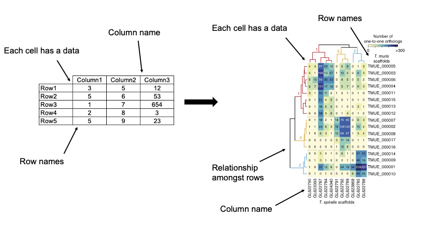

**Figure 1** - Data to figure.

There is now the exciting research discipline of Data Science that allows you to “turn raw data into understanding, insight and knowledge”. Before we start, we need to cite the materials that we have been inspired by and reformatted to make use of helminth related data in this course:

- **R for Data Science** written by Hadley Wickham and Garrett Grolemund (will now be referred as R4DS. https://r4ds.had.co.nz/ )
- **A ModernDive into R and the Tidyverse** written by Chester Ismay and Albert Y. Kim (will be referred as ModernDive; https://moderndive.com/index.html )

These books have been designed for absolute beginners to learn all the basics of R. They are free online and we encourage you to read further in your own time.

## Part 1: Introduction to R

In this module, we are introducing you to the programming language R via RStudio. So what is the difference between the two? You should think of RStudio as a car’s shiny dashboard and R as the engine. “More precisely, R is a programming language that runs computations, while RStudio is an integrated development environment (IDE) that provides an interface by adding many convenient features and tools. So just as the way of having access to a speedometer, rearview mirrors, and a navigation system makes driving much easier, using RStudio’s interface makes using R much easier as well.” ([ModernDive](https://moderndive.com/index.html)) .

R can certainly be run independently from RStudio - you can type “R” on the command line (providing it is installed - it is installed on your VM) - and the R command line prompt will appear. Sometimes in may in fact be necessary to run from the commandline, especially if you have a large computational task that requires sending jobs to a high preformance computing cluster. However, for the most part, you will find RStudio will be sufficient for what you need. If you want to download RStudio later on your own personal computer, R will automatically be installed with it in the background.

Let’s get started by opening Rstudio on your VM by double-clicking on the RStudio icon on the VM desktop.

After RStudio opens, you should see something similar like **Figure 3**

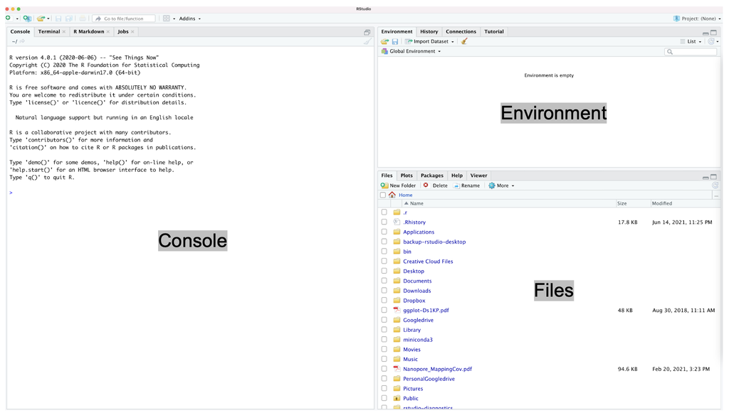

**Figure 3** - RStudio interface to R.

### R as a calculator

To code in R, you can start by clicking on the Console panel. It is typically the bottom left panel. Type something, and press **Enter/Return**

```r
# Some housekeeping - if you see text after the hash '#' symbol throguhout the code, it is a comment or
# instruction and not actual code (just like this!). It means that you do not have to type it in to the
# command line. Making comments in your code is actually really important - it allows you to remember what
# you have done, describe a result or process, and makes it much easier for someone else to read, understand,
# and reuse your code. It is a great habit to have!


# R in its basic form is a fancy calculator. Lets try this out. Once you have typed the equation, press enter
# to complete the expression

# First, a simple one. We are going to do 2 plus 3.
2 + 3

# We can do multiplications
2 * 3

# and division
2 / 3

# By simply pressing return/enter, you get a complete expression
1


# An incomplete expression will result in continuation prompt, indicated by the "+" symbol.
3+
  1111+
  1000
```

Simple 😎 , isn’t it?

### Assignment operator

The calculations alone will be meaningless if we don’t store them for later use. We can save the output of our command using the assignment operator **<-** to create a new **variable**.

```r
# "<-" is the assignment operator. Let's assign the number 5 to the variable "x".
x <- 5

# Next, assign 10 to y
y <- 10

# To check if the assignments are successful, you can always simply type x or y and press return
x
y

# We can perform calculations on data stored in a variable
x + y
x * y

# Like all programming languages, R is case sensitive. For example, the lower-case variable "x" is not the
# same as the upper-case variable "X"
X <- 20

# Test this by comparing the two variables
x
X

# We can overwrite variables by simply reassigning it. Previously, we assigned 5 to x. However....
x <- 10
x

# In the same way that we can perform caluclations using data stored in variables, we can also assign the
# output of that calculation to a new variable.
z <- x + y + X
z
```

*Exercises*  
1. Calculate the number of minutes in a single day by first assigning and then multiplying a `hour` variable and a `minutes` variable

```r
# how many hours are in a day? I (or everyone) wish there were 48 but there are only 24 hours..
hour <- 24
# please continue
```

2. Congratulations! you have won £100 (only for the exercise doh! ), but have to split it with your classmates. How much money will each of you get? So first you’d have to find out how many participants are in this course and assign a varibale. Will you share with the trainers? Please?

### R data structure

In order to start appreciating the power of R, the data needs to be organised or “tidied” in such a way so that calculations can be performed on them. There are many data types and structures in R. For simplicity we will introduce only two data structures: **vector** and **data frame**, and two data types: **numeric** (numbers) and **character** (text based).

A vector is the simplest data structure in R. It essentially contains a series of values of the same type. Data frames are a collection of vectors in columns. Think of it like Excel spreadsheets, where each row represents a sample, and each variable measured in a column. To iterate:

Rows represent samples E.g., sample A in Row 1, sample B in Row 2, and so on….

And all the values of the same variable must go in the same column. We can have multiple columns with multiple, different data types, for example, age, sex, RPKM, numbers, whatever.

We note here that there are newer and more intuitive ways of manipulation of data frame-type data, and we will use `tibble` from the `dplyr` package later in the module.

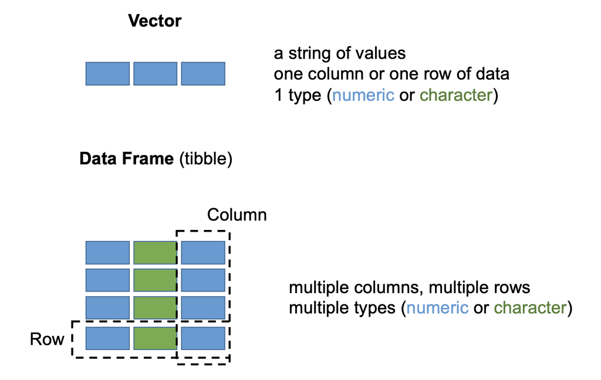

**Figure 4** - Two data struture used in this module

```r
# Lets explore what a vector looks like. Assign a vector of 1 to 10 to the variable x.
x <- c(1,2,3,4,5,6,7,8,9,10)
```

[output not shown]

```r
# the brackets


# Now that we have a vector, we can do calculations on all the values within a vector at
# the same time! Try the following:
x * 2

# and
x / 10 + 1

# you can even perform calculations on data stored in multiple vectors.
y <- c(1,2,3,4,5,6,7,8,9,10)

x * y

# using vectors becomes a very efficient way of storing and manipulating large data.
```